# Regressao Linear Simples

July 6, 2018

## Regressao Linear Quantidade de pessoas x KM

Nos fizemos a seguinte pergunta: “Sera que existe uma correlacao entre quantidade de pessoas e quantidade de passageiros? (quanto mais passageiros, maior a distancia e percorrida.”

## Bibliotecas

```r
#install.packages("readr")
library(readr)
```

## Leitura dos dados

Caso nao tenha ainda carregado o dataset, execute a linha abaixo. Caso contrario, nao e necessario.

```r
dtTrain = read_csv("data/train.csv", locale = locale(encoding = "ISO-8859-1" ))
Distancia_Haversine  <- function (lng1, lat1 , lng2, lat2)
  {
      rad <- pi/180
      a1 <- lat1 * rad
      a2 <- lng1 * rad
      b1 <- lat2 * rad
      b2 <- lng2 * rad
      dlon <- b2 - a2
      dlat <- b1 - a1
      a <- (sin(dlat/2))^2 + cos(a1) * cos(b1) * (sin(dlon/2))^2
      c <- 2 * atan2(sqrt(a), sqrt(1 - a))
      R <- 6371
      d <- R * c
      return(d)
}

Distancia_Manhattan  <- function  (lat1, lng1, lat2, lng2)
  {
      a = Distancia_Haversine(lat1, lng1, lat1, lng2)
      b = Distancia_Haversine(lat1, lng1, lat2, lng1)
      return (a + b)
  }

dtTrain$EuclidianaKM <- Distancia_Haversine( dtTrain$pickup_longitude, dtTrain$pickup_latitude , dtTrain$dropoff_longitude, dtTrain$dropoff_latitude )

dtTrain$ManhattanKM <- Distancia_Manhattan( dtTrain$pickup_latitude,  dtTrain$pickup_longitude,  dtTrain$dropoff_latitude, dtTrain$dropoff_longitude )
```

A seguir poderemos observar que nao ha nenhuma correlacao entre a quantidade de passageiros e a distancia percorrida. Também reduzimos o dataset para rodar em menos tempo.

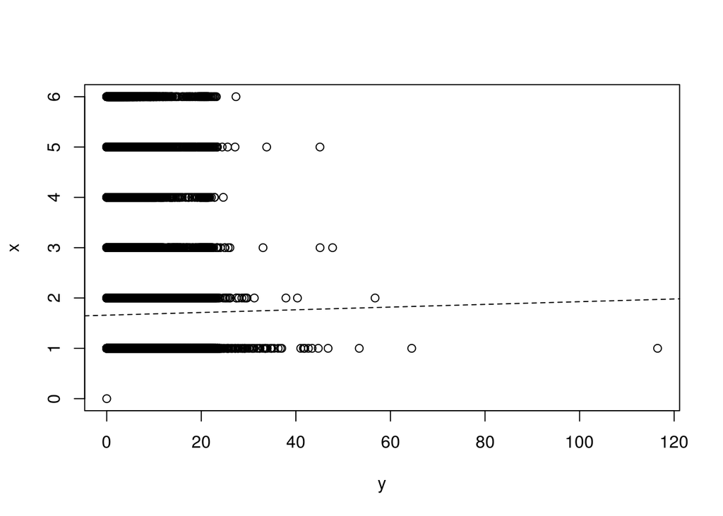

```r
dtTrain = head(dtTrain, n=100000)

x <- dtTrain$passenger_count
y <- dtTrain$EuclidianaKM

regressao <-lm(x~y)

plot(x~y)
abline(regressao,lty=2)
```

Para confirmar isso, podemos verificar a correlação entre as duas colunas no dataset. Poderemos observar que há uma correlação muito pequena entre as duas.

```r
cor(dtTrain$passenger_count, dtTrain$EuclidianaKM)
```

```
## [1] 0.008044376
```

Uma correlacao obvia, porem para fins didaticos: distancias euclidiana e de manhattan, pois quanto maior uma, maior a outra, conforme podera ser observado.

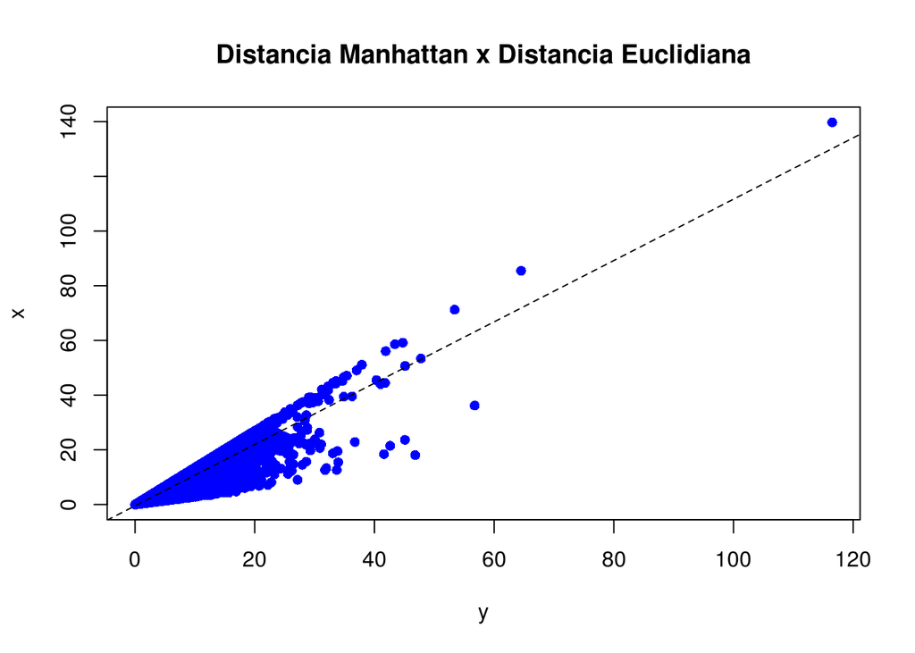

```r
dtTrain = head(dtTrain, n=100000)

x <- dtTrain$ManhattanKM
y <- dtTrain$EuclidianaKM

regressao <-lm(x~y)

plot(x~y, pch=16, col="blue", main="Distancia Manhattan x Distancia Euclidiana")
abline(regressao,lty=2)
```

Podemos também verificar quem sao os outliers dentro do conjunto de dados. Dependendo, poderiamos normalizá-los caso fosse aplicado algum modelo baseado nestas variáveis.

[figure not shown]

```r
par(mfrow=c(1, 2))
boxplot(dtTrain$ManhattanKM, main="Distancia Manhattan", sub=paste("Outliers: ", boxplot.stats(dtTrain$EuclidianaKM)$out))
boxplot(dtTrain$ManhattanKM, main="Distancia Euclidiana", sub=paste("Outliers: ", boxplot.stats(dtTrain$ManhattanKM)$out))
```

E neste caso, a correlacao entre as colunas sera muito proximo a 1, o que significa que há uma forte correlacao entre elas.

```r
cor(dtTrain$ManhattanKM, dtTrain$EuclidianaKM)
```

```
## [1] 0.9495215
```

Podemos até montar um modelo com uma assertividade de 95%. (porém sem utilidade prática).

```r
set.seed(100)
training_indexes <- sample(1:nrow(dtTrain), 0.7 * nrow(dtTrain))
training <- dtTrain[training_indexes, ]
test <- dtTrain[-training_indexes, ]
```

```r
model <- lm(EuclidianaKM ~ ManhattanKM ,data=training)
prediction <- predict(model, test)
```

```r
acuracia <- data.frame(cbind(actuals=test$EuclidianaKM, predicteds=prediction))
correlation_accuracy <- cor(acuracia)
correlation_accuracy
```

```
##             actuals predicteds
## actuals    1.000000   0.952978
## predicteds 0.952978   1.000000
```